# From Linear Regression to Mixed-Effects Models

A Mini-Lecture for Empirical Software Engineering

Empirical Methods in Software Engineering

2026-03-31

# Why This Matters for SE Research

Imagine you’re studying whether using a new static analysis tool reduces the number of bugs developers introduce. You recruit 30 developers, each of whom completes 5 coding tasks—some with the tool, some without. You count the bugs in each task.

You might think: “I’ll just run a linear regression predicting bug count from tool usage.” But there’s a problem. **Each developer contributed 5 data points.** Some developers are simply better coders than others. Their data points aren’t independent—they’re *clustered* by developer.

Ignoring this structure is one of the most common mistakes in empirical SE research. Mixed-effects models are the fix.

# Part 1: Quick Review of Linear Regression

## The Basic Idea

Linear regression models the relationship between a response variable $y$ and one or more predictors $x$:

$$y_i = \beta_0 + \beta_1 x_i +
\epsilon_i, \quad \epsilon_i \sim N(0, \sigma^2)$$

- $\beta_0$: intercept (baseline value of $y$)
- $\beta_1$: slope (how much $y$ changes per unit of $x$)
- $\epsilon_i$: residual error (assumed independent and normally distributed)

## A Simple SE Example

Let’s simulate a straightforward scenario: does code review time (in minutes) predict the number of defects found?

```r
library(ggplot2)
library(dplyr)

set.seed(42)

# Simulate: longer reviews find more defects
n <- 60
review_time <- runif(n, 10, 90)        # 10 to 90 minutes
defects_found <- 1.5 + 0.08 * review_time + rnorm(n, 0, 1.5)
defects_found <- pmax(round(defects_found), 0)  # non-negative integers

df_simple <- data.frame(review_time, defects_found)

# Fit a simple linear model
lm_simple <- lm(defects_found ~ review_time, data = df_simple)
summary(lm_simple)
```

```
##
## Call:
## lm(formula = defects_found ~ review_time, data = df_simple)
##
## Residuals:
##     Min      1Q  Median      3Q     Max
## -4.1482 -1.0362  0.3900  0.7861  2.6207
##
## Coefficients:
##             Estimate Std. Error t value Pr(>|t|)
## (Intercept) 1.274665   0.461239   2.764  0.00765 **
## review_time 0.084653   0.007622  11.106 5.51e-16 ***
## ---
## Signif. codes:  0 '***' 0.001 '**' 0.01 '*' 0.05 '.' 0.1 ' ' 1
##
## Residual standard error: 1.407 on 58 degrees of freedom
## Multiple R-squared:  0.6802, Adjusted R-squared:  0.6747
## F-statistic: 123.3 on 1 and 58 DF,  p-value: 5.512e-16
```

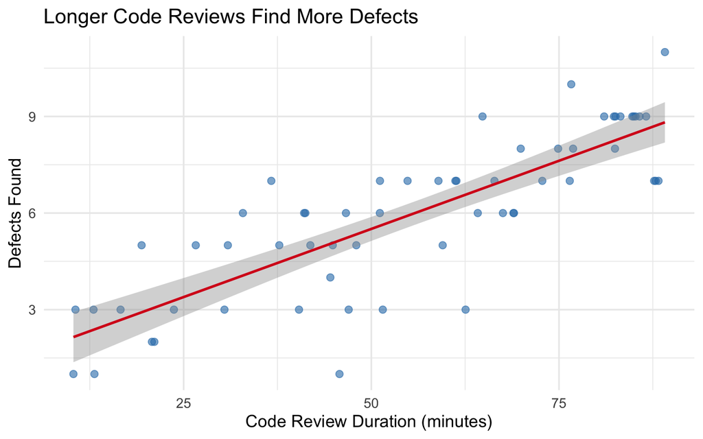

Simple linear regression: review time vs. defects found.

```r
ggplot(df_simple, aes(x = review_time, y = defects_found)) +
  geom_point(alpha = 0.6, size = 2.5, color = "#2c7bb6") +
  geom_smooth(method = "lm", se = TRUE, color = "#d7191c", linewidth = 1) +
  labs(
    x = "Code Review Duration (minutes)",
    y = "Defects Found",
    title = "Longer Code Reviews Find More Defects"
  ) +
  theme_minimal(base_size = 14)
```

### Reading the Output

The key things to look at:

- **Estimate for `review_time`**: the slope. Here, each additional minute of review is associated with finding ~0.08 more defects.
- **p-value**: is the relationship statistically distinguishable from zero?
- **$R^2$**: how much variance in defects does review time explain?

## The Critical Assumption We’re About to Break

Linear regression assumes every observation is **independent**. In the example above, each row is one review from one person—that’s fine.

But in SE research, our data almost always has **structure**:

- Multiple commits from the **same developer**
- Multiple releases from the **same project**
- Multiple tasks completed by the **same participant**
- Multiple files in the **same module**

When observations are grouped, they violate independence. Observations within the same group tend to be more similar to each other than to observations from other groups. This is the problem mixed-effects models solve.

# Part 2: The Problem With Ignoring Groups

## A More Realistic SE Scenario

Let’s make our example realistic. Now **8 developers** each review **8 code submissions**. Some developers are inherently more thorough than others.

```r
set.seed(123)

n_devs <- 8
n_reviews <- 8

# Each developer has a personal "baseline thoroughness"
dev_intercepts <- rnorm(n_devs, mean = 0, sd = 2.5)

sim_data <- expand.grid(
  developer = factor(paste0("Dev_", LETTERS[1:n_devs])),
  review_id = 1:n_reviews
) %>%
  mutate(
    dev_idx = as.numeric(developer),
    review_time = runif(n(), 10, 90),
    # Each dev has their own baseline (intercept), but same slope
    defects_found = 2 + dev_intercepts[dev_idx] + 0.06 * review_time +
                    rnorm(n(), 0, 1),
    defects_found = pmax(round(defects_found), 0)
  )
```

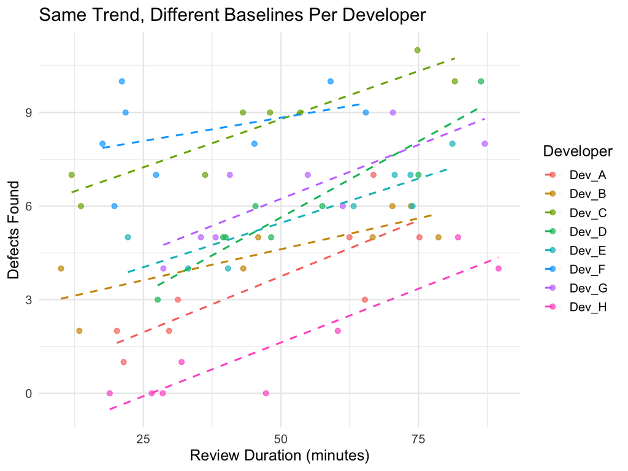

The same relationship, but each developer has a different baseline.

```r
ggplot(sim_data, aes(x = review_time, y = defects_found, color = developer)) +
  geom_point(alpha = 0.7, size = 2) +
  geom_smooth(method = "lm", se = FALSE, linewidth = 0.8, linetype = "dashed") +
  labs(
    x = "Review Duration (minutes)",
    y = "Defects Found",
    title = "Same Trend, Different Baselines Per Developer",
    color = "Developer"
  ) +
  theme_minimal(base_size = 14) +
  theme(legend.position = "right")
```

## What Happens If We Ignore the Grouping?

```r
lm_naive <- lm(defects_found ~ review_time, data = sim_data)
summary(lm_naive)
```

```
##
## Call:
## lm(formula = defects_found ~ review_time, data = sim_data)
##
## Residuals:
##     Min      1Q  Median      3Q     Max
## -5.5284 -1.6478 -0.1315  2.0052  5.7008
##
## Coefficients:
##             Estimate Std. Error t value Pr(>|t|)
## (Intercept)  3.30810    0.76055    4.35 5.18e-05 ***
## review_time  0.04696    0.01427    3.29  0.00165 **
## ---
## Signif. codes:  0 '***' 0.001 '**' 0.01 '*' 0.05 '.' 0.1 ' ' 1
##
## Residual standard error: 2.561 on 62 degrees of freedom
## Multiple R-squared:  0.1487, Adjusted R-squared:  0.1349
## F-statistic: 10.83 on 1 and 62 DF,  p-value: 0.001653
```

This model **pools all observations** as if they came from unrelated individuals. The problems:

### The “Just Add a Dummy Variable” Approach

You might think: “I’ll add `developer` as a predictor.”

```r
lm_fixed_dev <- lm(defects_found ~ review_time + developer, data = sim_data)
summary(lm_fixed_dev)
```

```
##
## Call:
## lm(formula = defects_found ~ review_time + developer, data = sim_data)
##
## Residuals:
##     Min      1Q  Median      3Q     Max
## -1.6424 -0.6206 -0.1465  0.5309  2.4513
##
## Coefficients:
##                 Estimate Std. Error t value Pr(>|t|)
## (Intercept)     0.660206   0.444287   1.486 0.142992
## review_time     0.061023   0.005796  10.529 8.54e-15 ***
## developerDev_B  0.900889   0.499735   1.803 0.076910 .
## developerDev_C  5.071424   0.499327  10.157 3.19e-14 ***
## developerDev_D  2.014455   0.500454   4.025 0.000176 ***
## developerDev_E  1.719502   0.503148   3.417 0.001196 **
## developerDev_F  5.600659   0.504016  11.112 1.12e-15 ***
## developerDev_G  2.537962   0.500306   5.073 4.78e-06 ***
## developerDev_H -2.098738   0.499369  -4.203 9.76e-05 ***
## ---
## Signif. codes:  0 '***' 0.001 '**' 0.01 '*' 0.05 '.' 0.1 ' ' 1
##
## Residual standard error: 0.9986 on 55 degrees of freedom
## Multiple R-squared:  0.8852, Adjusted R-squared:  0.8685
## F-statistic:    53 on 8 and 55 DF,  p-value: < 2.2e-16
```

This is called a **fixed-effects approach** and it works for *this* dataset, but it has practical problems:

| Issue | Why It Matters |
| --- | --- |
| Uses up degrees of freedom | With 50 developers, you burn 49 df on dummy variables |
| Can’t generalize | Results apply only to *these specific* developers |
| Can’t handle crossed designs | What if tasks are *also* grouped (e.g., by project)? |
| Breaks with unbalanced data | Some developers did 3 reviews, others did 12 |

**Mixed-effects models solve all of these problems.**

# Part 3: Mixed-Effects Models

## The Key Idea

A mixed-effects model separates your predictors into two types:

- **Fixed effects**: the variables you care about and want to estimate (e.g., review time, tool usage). These generalize to the population.
- **Random effects**: grouping variables that introduce structured variability (e.g., developer, project). You’re not interested in *specific* group values— you want to *account for* the fact that groups differ.

The model for our example:

$$y_{ij} = \underbrace{(\beta_0 +
u_{0j})}_{\text{intercept for dev } j} + \beta_1 \cdot
\text{review\_time}_{ij} + \epsilon_{ij}$$

where:

- $\beta_0$: **grand mean** intercept (fixed)
- $u_{0j} \sim N(0, \tau^2)$: **random intercept** for developer $j$ (how much dev $j$ deviates from the grand mean)
- $\beta_1$: **fixed slope** for review time
- $\epsilon_{ij} \sim N(0, \sigma^2)$: residual error

The random intercepts $u_{0j}$ are assumed to come from a normal distribution. This is what makes them “random”—we’re modeling the *distribution* of developer effects, not estimating each one individually.

## Fitting the Model in R

```r
library(lme4)

# Random intercept for developer
mixed_model <- lmer(defects_found ~ review_time + (1 | developer),
                    data = sim_data)
summary(mixed_model)
```

```
## Linear mixed model fit by REML ['lmerMod']
## Formula: defects_found ~ review_time + (1 | developer)
##    Data: sim_data
##
## REML criterion at convergence: 217.8
##
## Scaled residuals:
##     Min      1Q  Median      3Q     Max
## -1.6776 -0.6242 -0.1496  0.5107  2.5216
##
## Random effects:
##  Groups    Name        Variance Std.Dev.
##  developer (Intercept) 6.2673   2.5034
##  Residual              0.9971   0.9986
## Number of obs: 64, groups:  developer, 8
##
## Fixed effects:
##             Estimate Std. Error t value
## (Intercept) 2.642825   0.936668   2.822
## review_time 0.060726   0.005791  10.486
##
## Correlation of Fixed Effects:
##             (Intr)
## review_time -0.299
```

### Reading the Output

**Random effects section:**

- `developer (Intercept)` variance: how much developers vary in their baseline thoroughness ($\tau^2$).
- `Residual` variance: leftover noise after accounting for developer differences ($\sigma^2$).
- The **Intraclass Correlation Coefficient (ICC)** tells you what fraction of the total variance is explained by the grouping:

```r
vc <- as.data.frame(VarCorr(mixed_model))
tau2 <- vc$vcov[1]   # developer variance
sig2 <- vc$vcov[2]   # residual variance

icc <- tau2 / (tau2 + sig2)
cat(sprintf("ICC = %.3f\n", icc))
```

```
## ICC = 0.863
```

```r
cat(sprintf("%.0f%% of the variance in defects is due to developer differences.\n",
            icc * 100))
```

```
## 86% of the variance in defects is due to developer differences.
```

**Fixed effects section:**

- `review_time` estimate: same interpretation as linear regression—each additional minute of review is associated with finding more defects.
- Standard errors are now **correct** because the model knows observations within a developer are correlated.

**Interpreting the ICC:**

An ICC of ~0.40 or higher, in this case, means that ignoring the grouping would be a serious mistake.

The impact of ignoring grouping depends on two things together: the ICC and the cluster size (how many observations per group). The combination determines how badly your standard errors are inflated. The relevant concept is the design effect, which approximates how much the variance of your estimates is inflated by clustering:

$\text{DEFF} = 1 + (m - 1) \times \text{ICC}$,

where $m$ is the average cluster size.

With 8 observations per developer and ICC = 0.863:

$\text{DEFF} = 1 + (8 - 1) \times 0.863 = 1 + 6.04 = 7.04$

## Visualizing the Random Effects

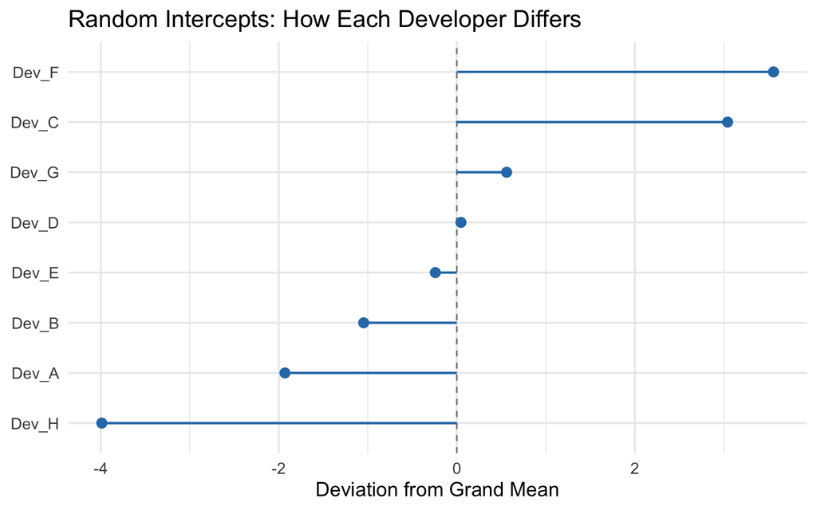

Each developer’s estimated deviation from the grand mean intercept.

```r
ranefs <- ranef(mixed_model)$developer
ranefs$developer <- rownames(ranefs)
names(ranefs)[1] <- "intercept_offset"

ggplot(ranefs, aes(x = reorder(developer, intercept_offset),
                   y = intercept_offset)) +
  geom_hline(yintercept = 0, linetype = "dashed", color = "grey50") +
  geom_point(size = 3, color = "#2c7bb6") +
  geom_segment(aes(xend = developer, y = 0, yend = intercept_offset),
               color = "#2c7bb6", linewidth = 0.8) +
  coord_flip() +
  labs(
    x = NULL,
    y = "Deviation from Grand Mean",
    title = "Random Intercepts: How Each Developer Differs"
  ) +
  theme_minimal(base_size = 14)
```

## Side-by-Side: Naive LM vs. Mixed Model

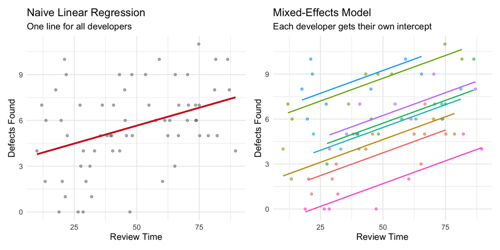

Left: one line for everyone (naive). Right: developer-specific intercepts (mixed model).

```r
library(patchwork)

# Get mixed model predictions
sim_data$pred_mixed <- predict(mixed_model)

p1 <- ggplot(sim_data, aes(x = review_time, y = defects_found)) +
  geom_point(alpha = 0.5, color = "grey40") +
  geom_smooth(method = "lm", color = "#d7191c", linewidth = 1.2, se = FALSE) +
  labs(title = "Naive Linear Regression",
       subtitle = "One line for all developers",
       x = "Review Time", y = "Defects Found") +
  theme_minimal(base_size = 13)

p2 <- ggplot(sim_data, aes(x = review_time, y = defects_found,
                            color = developer)) +
  geom_point(alpha = 0.6, size = 1.5) +
  geom_line(aes(y = pred_mixed), linewidth = 0.8) +
  labs(title = "Mixed-Effects Model",
       subtitle = "Each developer gets their own intercept",
       x = "Review Time", y = "Defects Found") +
  theme_minimal(base_size = 13) +
  theme(legend.position = "none")

p1 + p2
```

The naive model reports one big sigma^2 and calls it “noise,” while the mixed model reveals that a substantial chunk of it was actually systematic developer differences — not noise at all.

```r
# Naive LM: all unexplained variance in one bucket
sigma_naive <- sigma(lm_naive)^2

# Mixed model: variance split into developer + residual
vc <- as.data.frame(VarCorr(mixed_model))
tau2 <- vc$vcov[1]   # developer
sig2 <- vc$vcov[2]   # residual

cat(sprintf("Naive LM residual variance:   %.2f\n", sigma_naive))
```

```
## Naive LM residual variance:   6.56
```

```r
cat(sprintf("Mixed model τ² + σ²:          %.2f  (τ²=%.2f + σ²=%.2f)\n",
            tau2 + sig2, tau2, sig2))
```

```
## Mixed model τ² + σ²:          7.26  (τ²=6.27 + σ²=1.00)
```

# Part 4: Going Further

## Random Slopes

So far we assumed every developer has the **same slope** (same benefit from spending more time). But what if some developers benefit more from longer reviews than others?

$$y_{ij} = (\beta_0 + u_{0j}) + (\beta_1 +
u_{1j}) \cdot \text{review\_time}_{ij} + \epsilon_{ij}$$

Now each developer has their own intercept *and* their own slope.

```r
# Random intercept AND random slope for review_time
mixed_slopes <- lmer(
  defects_found ~ review_time + (1 + review_time | developer),
  data = sim_data
)
summary(mixed_slopes)
```

```
## Linear mixed model fit by REML ['lmerMod']
## Formula: defects_found ~ review_time + (1 + review_time | developer)
##    Data: sim_data
##
## REML criterion at convergence: 216.7
##
## Scaled residuals:
##     Min      1Q  Median      3Q     Max
## -1.8263 -0.6093 -0.1294  0.5092  2.3855
##
## Random effects:
##  Groups    Name        Variance  Std.Dev. Corr
##  developer (Intercept) 7.8798259 2.80710
##            review_time 0.0001107 0.01052  -0.70
##  Residual              0.9490999 0.97422
## Number of obs: 64, groups:  developer, 8
##
## Fixed effects:
##             Estimate Std. Error t value
## (Intercept) 2.631310   1.037221   2.537
## review_time 0.060470   0.006797   8.897
##
## Correlation of Fixed Effects:
##             (Intr)
## review_time -0.590
## optimizer (nloptwrap) convergence code: 0 (OK)
## Model failed to converge with max|grad| = 0.0496749 (tol = 0.002, component 1)
```

**When to use random slopes:**

- When you have theoretical reason to believe the effect of your predictor varies across groups.
- When you have enough data per group to estimate them (rule of thumb: 5+ observations per group, ideally more).
- Barr et al. (2013) recommend “maximal” random effects structures justified by the design—but in practice, you often need to simplify for convergence.

## Multiple Grouping Factors

SE data often has **crossed** or **nested** random effects. For instance, if developers review code from multiple projects:

```r
# Crossed random effects: developers AND projects
lmer(defects ~ review_time + (1 | developer) + (1 | project), data = mydata)

# Nested: developers within teams
lmer(defects ~ review_time + (1 | team/developer), data = mydata)
```

This is where mixed models really shine over the dummy-variable approach— handling complex grouping structures naturally.

# Part 5: The Cheat Sheet

## When to Use What

| Situation | Model |
| --- | --- |
| One observation per subject, no grouping | Linear regression (lm) |
| Repeated measures, few groups (< 5) | Fixed effects / ANOVA may work |
| Repeated measures, groups are a sample from a larger population | Mixed-effects model (lmer) |
| Multiple crossed grouping factors | Mixed-effects model (lmer) |
| You want to generalize beyond the specific groups in your data | Mixed-effects model (lmer) |

## Common SE Research Scenarios

| Study Design | Fixed Effects | Random Effects |
| --- | --- | --- |
| Tool evaluation with repeated tasks | tool (on/off), task difficulty | participant, task |
| Mining defects across projects | code metrics (LOC, complexity) | project, module |
| Developer productivity over time | time period, methodology | developer |
| Code review effectiveness | review type, reviewer experience | pull request, repository |

## Quick Reference: `lmer` Syntax

| Formula | Meaning |
| --- | --- |
| `(1 \\| group)` | Random intercept per group |
| `(1 + x \\| group)` | Random intercept + random slope for x |
| `(1 \\| g1) + (1 \\| g2)` | Crossed random effects |
| `(1 \\| g1/g2)` | g2 nested within g1 |
| `(0 + x \\| group)` | Random slope only (no random intercept) |

## Reporting Results

When you publish, report:

1. The **fixed effects** with estimates, standard errors, and confidence intervals.
2. The **random effects** variance components (and ICC if relevant).
3. The number of observations *and* the number of groups.
4. How you handled model selection and convergence.

```r
# Use confint for confidence intervals (profile likelihood)
# confint(mixed_model)  # can be slow; use method="Wald" for speed

# For p-values, use lmerTest
library(lmerTest)

mixed_with_p <- lmer(defects_found ~ review_time + (1 | developer),
                     data = sim_data)
summary(mixed_with_p)
```

```
## Linear mixed model fit by REML. t-tests use Satterthwaite's method [
## lmerModLmerTest]
## Formula: defects_found ~ review_time + (1 | developer)
##    Data: sim_data
##
## REML criterion at convergence: 217.8
##
## Scaled residuals:
##     Min      1Q  Median      3Q     Max
## -1.6776 -0.6242 -0.1496  0.5107  2.5216
##
## Random effects:
##  Groups    Name        Variance Std.Dev.
##  developer (Intercept) 6.2673   2.5034
##  Residual              0.9971   0.9986
## Number of obs: 64, groups:  developer, 8
##
## Fixed effects:
##              Estimate Std. Error        df t value Pr(>|t|)
## (Intercept)  2.642825   0.936668  8.421160   2.822   0.0213 *
## review_time  0.060726   0.005791 55.178496  10.486 9.54e-15 ***
## ---
## Signif. codes:  0 '***' 0.001 '**' 0.01 '*' 0.05 '.' 0.1 ' ' 1
##
## Correlation of Fixed Effects:
##             (Intr)
## review_time -0.299
```

# Key Takeaways

# Further Reading

- **Winter, B. (2020).** *Statistics for Linguists: An Introduction Using R.* Chapters 10–12 give an excellent accessible introduction to mixed models.
- **Barr, D. J., Levy, R., Scheepers, C., & Tily, H. J. (2013).** Random effects structure for confirmatory hypothesis testing. *Journal of Memory and Language,* 68(3), 255–278.
- **Bates, D., Mächler, M., Bolker, B., & Walker, S. (2015).** Fitting linear mixed-effects models using lme4. *Journal of Statistical Software,* 67(1), 1–48.

*This lecture was designed for PhD students in software engineering. The examples use simulated data to make the concepts transparent. In your own research, check model assumptions (normality of residuals, homoscedasticity) and consider whether a generalized linear mixed model (GLMM) is more appropriate for your outcome variable (e.g., Poisson for counts, logistic for binary outcomes).*